# Communities & Crime : Comment expliquer le nombre de crimes ?

Mathis CORDIER

L’objectif de ce projet est de prédire et expliquer au mieux le nombre de crimes en fonction d’un grand nombre de variables. C’est donc un problème de régression sur lequel nous allons pouvoir essayer un grand nombre de méthodes d’apprentissage statistique. Vous pouvez retrouver les informations concernant ce jeu de données sur https://archive.ics.uci.edu/ml/datasets/Communities+and+Crime. Les données brutes se présentant sous la forme de 1993 lignes et 128 colonnes. La variable que nous souhaitons expliquer se trouve sur la dernière colonne du tableau.

Nous allons tout d’abord devoir traiter le grand nombre de données manquantes, puis nous passerons à la mise en place de l’ensemble des techniques de régression.

# Pre-processing

Premièrement, nous commençons par importer les données qui sont sous forme de 2 fichiers. Le fichier “communities.data” contient les données brutes et le fichier “communities.names” contient lui le nom des variables et leur signification.

```r
# Importation
library(stringr)
df = read.csv("communities.data")
cols = readLines("communities.names")[76:203]
vars = c()
for (c in cols) {vars = c(vars,str_split(c," ")[[1]][2])}
colnames(df) = vars
n=nrow(df)
```

Nous obtenons alors un tableau de données `df` contenant la totalité des données.

```r
Y = df[,length(df)]
X = df[,6:(length(df)-1)]
#summary(X)
str(X,list.len=5)
```

```
## 'data.frame':    1993 obs. of  122 variables:
##  $ population           : num  0 0 0.04 0.01 0.02 0.01 0.01 0.03 0.01 0.13 ...
##  $ householdsize        : num  0.16 0.42 0.77 0.55 0.28 0.39 0.74 0.34 0.4 0.71 ...
##  $ racepctblack         : num  0.12 0.49 1 0.02 0.06 0 0.03 0.2 0.06 0.15 ...
##  $ racePctWhite         : num  0.74 0.56 0.08 0.95 0.54 0.98 0.46 0.84 0.87 0.07 ...
##  $ racePctAsian         : num  0.45 0.17 0.12 0.09 1 0.06 0.2 0.02 0.3 1 ...
##   [list output truncated]
```

Les 5 premières colonnes du fichier brut sont soit des variables qualitatives, soit elles possèdent un très grand nombre de données manquantes. Nous les supprimons donc afin que le tableau de données ne soit composé que de variables quantitatives sans valeurs manquantes. Nous continuons donc de “laver” la base de données car il subsiste un grand nombre de variables contenant des “?” alors que ces variables sont quantitatives. Ce sont en réalité des valeurs manquantes.

```r
count_intero = as.numeric(apply(X=="?",2,sum))
count_intero
```

```
##   [1]    0    0    0    0    0    0    0    0    0    0    0    0    0    0
##  [15]    0    0    0    0    0    0    0    0    0    0    0    1    0    0
##  [29]    0    0    0    0    0    0    0    0    0    0    0    0    0    0
##  [43]    0    0    0    0    0    0    0    0    0    0    0    0    0    0
##  [57]    0    0    0    0    0    0    0    0    0    0    0    0    0    0
##  [71]    0    0    0    0    0    0    0    0    0    0    0    0    0    0
##  [85]    0    0    0    0    0    0    0    0    0    0    0    0 1675 1675
##  [99] 1675 1675 1675 1675 1675 1675 1675 1675 1675 1675 1675 1675 1675 1675
## [113] 1675    0    0    0 1675 1675 1675 1675    0 1675
```

```r
index_intero = which(count_intero>100)
X = X[,-index_intero]
```

Nous avons enlever les variables avec un nombre très grand de valeurs manquantes. Il reste maintenant une variable pour laquelle il manque une donnée.

```r
count_intero = as.numeric(apply(X=="?",2,sum))
count_intero
```

```
##   [1] 0 0 0 0 0 0 0 0 0 0 0 0 0 0 0 0 0 0 0 0 0 0 0 0 0 1 0 0 0 0 0 0 0 0 0
##  [36] 0 0 0 0 0 0 0 0 0 0 0 0 0 0 0 0 0 0 0 0 0 0 0 0 0 0 0 0 0 0 0 0 0 0 0
##  [71] 0 0 0 0 0 0 0 0 0 0 0 0 0 0 0 0 0 0 0 0 0 0 0 0 0 0 0 0 0 0
```

```r
index_intero = which(count_intero>0)
index_intero
```

```
## [1] 26
```

On décide alors de remplacer cette donnée manquante par la médiane de la variable concernée. Ici, il n’aurait pas été intelligent de supprimer la variable ou l’individu étant donné qu’il ne manque qu’une donnée. Le choix de mettre la médiane à la place est motivée par le fait qu’elle ne créera pas de pseudo “pré-apprentissage”. En effet, si on choisit de mettre une valeur proche de celles que possèdent les individus qui lui sont proches, alors nous sommes déjà dans une phase d’apprentissage qui peut être erronée.

```r
index_intero = which(X[,26]=="?")
index_intero
```

```
## [1] 130
```

```r
val_intero = median(as.numeric(as.character(X[-130,26])))
X[,26] = as.character(X[,26])
X[130,26] = "0"
X[,26] = as.numeric(X[,26])
X[130,26] = val_intero

str(X)
```

```
## 'data.frame':    1993 obs. of  100 variables:
##  $ population           : num  0 0 0.04 0.01 0.02 0.01 0.01 0.03 0.01 0.13 ...
##  $ householdsize        : num  0.16 0.42 0.77 0.55 0.28 0.39 0.74 0.34 0.4 0.71 ...
##  $ racepctblack         : num  0.12 0.49 1 0.02 0.06 0 0.03 0.2 0.06 0.15 ...
##  $ racePctWhite         : num  0.74 0.56 0.08 0.95 0.54 0.98 0.46 0.84 0.87 0.07 ...
##  $ racePctAsian         : num  0.45 0.17 0.12 0.09 1 0.06 0.2 0.02 0.3 1 ...
##  $ racePctHisp          : num  0.07 0.04 0.1 0.05 0.25 0.02 1 0 0.03 0.41 ...
##  $ agePct12t21          : num  0.26 0.39 0.51 0.38 0.31 0.3 0.52 0.38 0.9 0.4 ...
##  $ agePct12t29          : num  0.59 0.47 0.5 0.38 0.48 0.37 0.55 0.45 0.82 0.52 ...
##  $ agePct16t24          : num  0.35 0.28 0.34 0.23 0.27 0.23 0.36 0.28 0.8 0.35 ...
##  $ agePct65up           : num  0.27 0.32 0.21 0.36 0.37 0.6 0.35 0.48 0.39 0.33 ...
##  $ numbUrban            : num  0.02 0 0.06 0.02 0.04 0.02 0 0.04 0.02 0.15 ...
##  $ pctUrban             : num  1 0 1 0.9 1 0.81 0 1 1 1 ...
##  $ medIncome            : num  0.31 0.3 0.58 0.5 0.52 0.42 0.16 0.17 0.54 0.49 ...
##  $ pctWWage             : num  0.72 0.58 0.89 0.72 0.68 0.5 0.44 0.47 0.59 0.71 ...
```

[output cut: 86 more lines]

```r
dim(X)
```

```
## [1] 1993  100
```

Nous avons alors notre jeu de données propre, prêt à être analyser. Nous séparons alors le jeu de données en 2. La partie de test ne sera jamais utiliser lors de la partie d’apprentissage statistique et servira uniquement à calculer la précision de l’algorithme en phase de prédiction.

```r
#Test/Train
poptest = sample(1:n,993)
poptrain = setdiff(1:n,poptest)
Xtest = as.matrix(X[poptest,])
Xtrain = as.matrix(X[poptrain,])
Ytest = Y[poptest]
Ytrain = Y[poptrain]
df_train = data.frame(Ytrain,Xtrain)

dim(Xtrain)
```

```
## [1] 1000  100
```

```r
dim(Xtest)
```

```
## [1] 993 100
```

On a alors notre jeu de données d’entraînement composé de 1000 lignes et 100 colonnes et notre jeu de données de test composé de 993 lignes et 100 colonnes. Les valeurs à prédire sont donc respetivement de taille 1000 et 993 pour `Ytrain` et `Ytest`.

# Apprentissage

Nous allons passer en revue les différentes méthodes puis nous comparerons, en fin de partie, la précision des prédictions.

## Régression linéaire

Nous pouvons alors commencer la partie d’apprentissage statistique. Il semble judicieux de commencer notre analyse par une “simple” régression linéaire. Bien que les données soient réparties sur 100 colonnes, elle nous servira dans le pire des cas de base de comparaison avec les autres méthodes.

```r
# REGRESSION LINEAIRE
reglin = lm(Ytrain~., df_train)
summary(reglin)
```

```
##
## Call:
## lm(formula = Ytrain ~ ., data = df_train)
##
## Residuals:
##      Min       1Q   Median       3Q      Max
## -0.46563 -0.06938 -0.01189  0.05123  0.66549
##
## Coefficients:
##                        Estimate Std. Error t value Pr(>|t|)
## (Intercept)            0.474632   0.282989   1.677 0.093849 .
## population             0.620720   0.570315   1.088 0.276719
## householdsize         -0.071833   0.125123  -0.574 0.566043
## racepctblack           0.232504   0.069698   3.336 0.000885 ***
## racePctWhite          -0.096074   0.077521  -1.239 0.215546
## racePctAsian           0.011216   0.048076   0.233 0.815578
## racePctHisp            0.025080   0.075086   0.334 0.738448
## agePct12t21            0.097652   0.145868   0.669 0.503379
## agePct12t29           -0.234490   0.228203  -1.028 0.304439
## agePct16t24           -0.146226   0.231744  -0.631 0.528213
## agePct65up             0.003279   0.143050   0.023 0.981716
## numbUrban             -0.979939   0.554436  -1.767 0.077492 .
## pctUrban               0.081130   0.022175   3.659 0.000268 ***
## medIncome              0.043185   0.246857   0.175 0.861167
## pctWWage              -0.137733   0.123328  -1.117 0.264376
## pctWFarmSelf           0.047303   0.029088   1.626 0.104257
## pctWInvInc            -0.136788   0.097404  -1.404 0.160564
## pctWSocSec             0.251406   0.151830   1.656 0.098104 .
## pctWPubAsst            0.030575   0.064006   0.478 0.632986
## pctWRetire            -0.096241   0.051096  -1.884 0.059952 .
## medFamInc             -0.043294   0.234587  -0.185 0.853620
## perCapInc              0.115598   0.272171   0.425 0.671137
## whitePerCap           -0.425889   0.213306  -1.997 0.046169 *
## blackPerCap           -0.046920   0.035299  -1.329 0.184107
## indianPerCap           0.001894   0.026632   0.071 0.943319
## AsianPerCap            0.007035   0.027866   0.252 0.800748
## OtherPerCap            0.045694   0.026661   1.714 0.086896 .
## HispPerCap             0.094140   0.035446   2.656 0.008050 **
## NumUnderPov            0.253567   0.202977   1.249 0.211901
## PctPopUnderPov        -0.291835   0.091557  -3.187 0.001485 **
```

[output cut: 62 more lines]

```
## PctForeignBorn        -0.151923   0.128395  -1.183 0.237025
## PctBornSameState       0.049001   0.059648   0.821 0.411585
## PctSameHouse85         0.016389   0.080908   0.203 0.839526
## PctSameCity85         -0.047773   0.053352  -0.895 0.370800
## PctSameState85         0.016328   0.058630   0.278 0.780695
## LandArea               0.029947   0.082265   0.364 0.715918
## PopDens               -0.043461   0.042691  -1.018 0.308927
## PctUsePubTrans        -0.019209   0.033032  -0.582 0.561045
## LemasPctOfficDrugUn   -0.014894   0.021483  -0.693 0.488311
## ---
## Signif. codes:  0 '***' 0.001 '**' 0.01 '*' 0.05 '.' 0.1 ' ' 1
##
## Residual standard error: 0.1289 on 899 degrees of freedom
## Multiple R-squared:  0.7042, Adjusted R-squared:  0.6713
## F-statistic: 21.41 on 100 and 899 DF,  p-value: < 2.2e-16
```

Nous pouvons donc voir le modèle rendu par le modèle linéaire. Nous allons maintenant calculer l’erreur de prédiction du modèle sur les données de test. Nous utiliserons comme moyen de comparaison la MSE.

```r
beta = as.numeric(reglin$coefficients)
Xtest_reg = as.matrix(cbind(rep(1,993),Xtest))
Ypred = Xtest_reg %*% beta
err_lm = sum((Ypred-Ytest)^2)/993
err_lm
```

```
## [1] 0.02108852
```

Le modèle contient un grand nombre de variables non significatives. Il est ici intéressant de voir, au sens de la régression linéaire, quelles variables sont celles qui ont un effet sur le taux de crimes.

```r
pval = as.numeric(summary(reglin)$coefficients[,4])
signif = which(pval<0.05)
imp_lm = summary(reglin)$coefficients[signif,]
imp_lm = imp_lm[order(imp_lm[,4]),]
imp_lm
```

```
##                          Estimate Std. Error   t value     Pr(>|t|)
## pctUrban               0.08113047 0.02217459  3.658714 0.0002682340
## racepctblack           0.23250433 0.06969816  3.335875 0.0008851486
## PctPopUnderPov        -0.29183467 0.09155655 -3.187480 0.0014847591
## HispPerCap             0.09413981 0.03544566  2.655891 0.0080499636
## HousVacant             0.31003155 0.11721536  2.644974 0.0083122527
## MalePctDivorce         0.90424215 0.35883328  2.519951 0.0119093653
## MalePctNevMarr         0.25116720 0.09976013  2.517711 0.0119847979
## PctPersOwnOccup       -1.20288640 0.48142692 -2.498586 0.0126465275
## PctPersDenseHous       0.27155172 0.11104081  2.445513 0.0146555073
## PctKids2Par           -0.51835548 0.22151517 -2.340045 0.0194993675
## PctBSorMore            0.25046527 0.11214712  2.233363 0.0257703580
## PctHousOwnOcc          1.10689502 0.50639567  2.185830 0.0290853502
## PctLess9thGrade       -0.19941596 0.09436265 -2.113293 0.0348506661
## PersPerRentOccHous    -0.24840806 0.11942878 -2.079968 0.0378112635
## PctRecImmig8           0.80242814 0.39412760  2.035960 0.0420470661
## whitePerCap           -0.42588921 0.21330617 -1.996610 0.0461687305
## MedOwnCostPctIncNoMtg -0.06994179 0.03535936 -1.978028 0.0482305495
```

Ce tableau représente le modèle linéaire auquel nous avons tronqué les variables non significatives au seuil de 5%. Il ne reste alors que les variables qui semblent liées avec la criminalité. Nous étudierons en fin de partie le lien entre ces variables et la criminalité et le sens de ces variables.

## Lasso

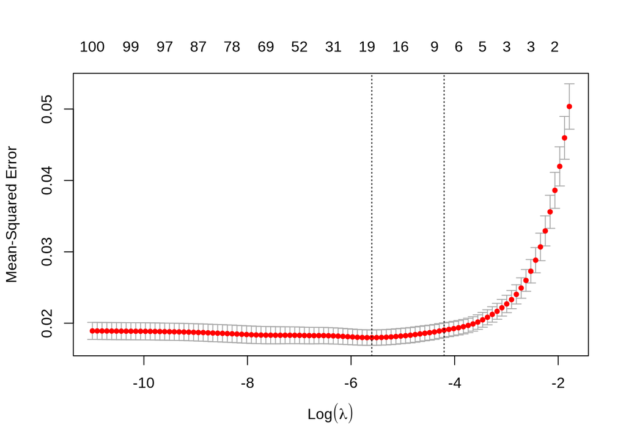

```r
# LASSO
library(glmnet)
cvlasso = cv.glmnet(Xtrain,Ytrain,alpha=1)
plot(cvlasso)
```

```r
lda = cvlasso$lambda.min
Ypred = predict(cvlasso, Xtest, s=lda)
err_lasso = sum((Ypred-Ytest)^2)/993
err_lasso
```

```
## [1] 0.02022632
```

## Ridge

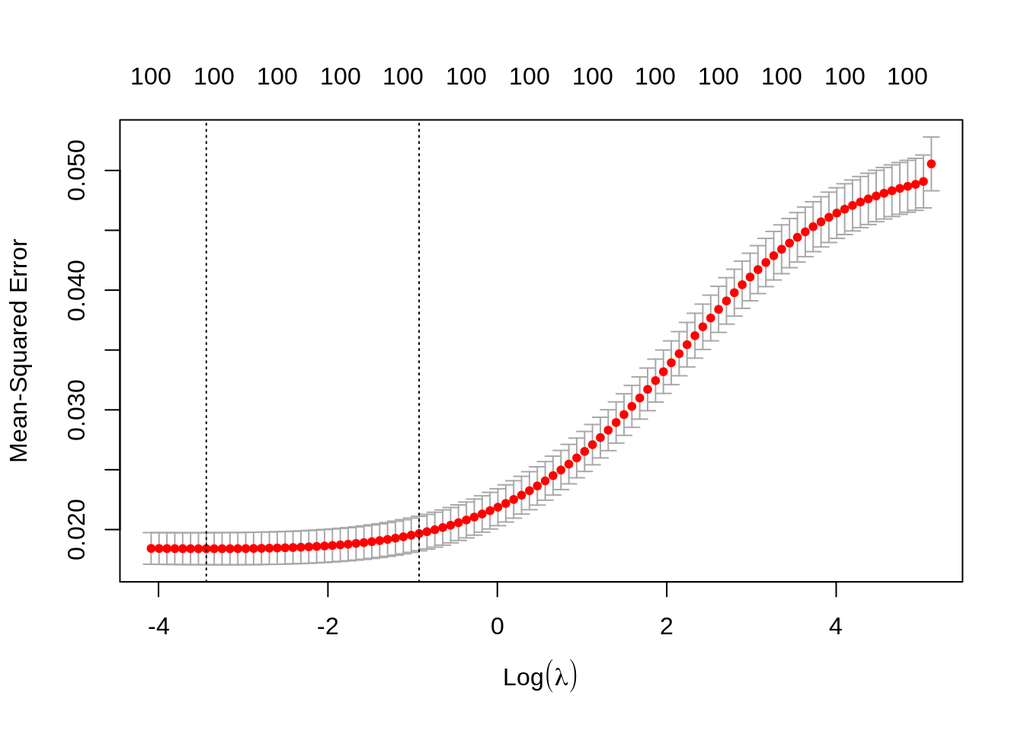

```r
# RIDGE
cvridge = cv.glmnet(Xtrain,Ytrain,alpha=0)
plot(cvridge)
```

```r
lda = cvridge$lambda.min
Ypred = predict(cvridge, Xtest, s=lda)
err_ridge = sum((Ypred-Ytest)^2)/993
err_ridge
```

```
## [1] 0.01994072
```

## Elastic net

```r
# ELASTIC NET
library(caret)
best_elnet = train(Xtrain,Ytrain,method="glmnet",trControl=trainControl("cv",number=5),tuneLength=10)
best_elnet$bestTune
```

|  | alpha | lambda |
| --- | --- | --- |
| 86 | 0.9 | 0.005104592 |

```r
Ypred = predict(best_elnet, Xtest)
err_e_net = sum((Ypred-Ytest)^2)/993
err_e_net
```

```
## [1] 0.02030526
```

## Random forest

```r
# RANDOM FOREST
library(randomForest)
fit = randomForest(Ytrain~., data=df_train, ntree=1000)
fit
```

```
##
## Call:
##  randomForest(formula = Ytrain ~ ., data = df_train, ntree = 1000)
##                Type of random forest: regression
##                      Number of trees: 1000
## No. of variables tried at each split: 33
##
##           Mean of squared residuals: 0.01831368
##                     % Var explained: 63.76
```

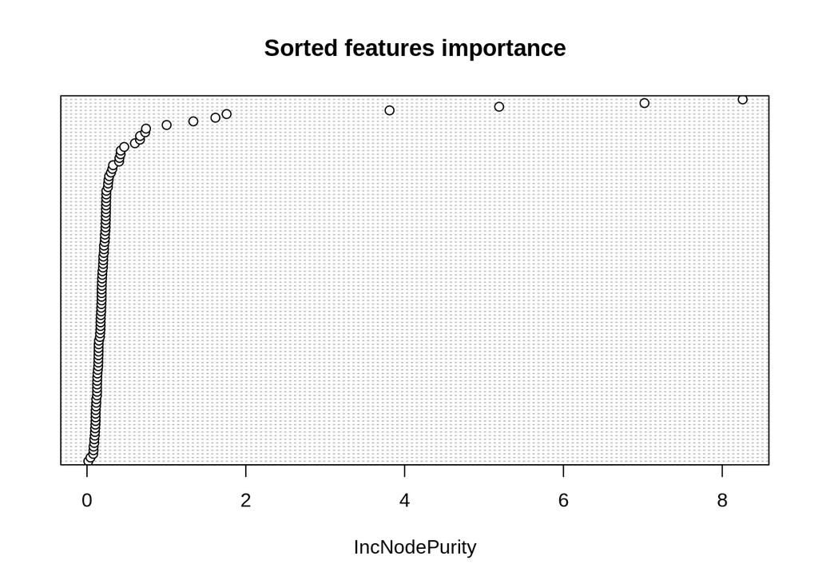

```r
varImpPlot(fit, labels="", n.var=100, main="Sorted features importance")
```

On peut aussi distinguer les 8 variables qui jouent un rôle dans ce modèle. Une nouvelle fois, nous comparerons ces résultats avec les autres modèles à la fin de la partie.

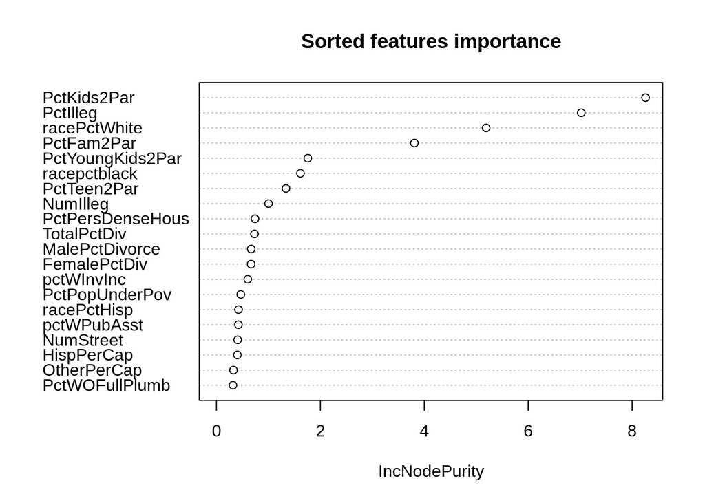

```r
varImpPlot(fit, n.var=20, main="Sorted features importance")
```

```r
imp_rf = fit$importance[order(fit$importance,decreasing=TRUE),][1:8]
Ypred = predict(fit, newdata=Xtest)
err_rf = sum((Ypred-Ytest)^2)/993
err_rf
```

```
## [1] 0.01937264
```

## Extrem gradient boosting

```r
# EXTREM GRADIENT BOOSTING
library(xgboost)
modxgb = xgboost(data = Xtrain,label = Ytrain,nround = 1000,verbose=0)
Ypred = predict(modxgb, Xtest)
err_xgb = sum((Ypred-Ytest)^2)/993
err_xgb
```

```
## [1] 0.02263628
```

## Réseaux de neurones

Nous passons directement nos données à keras car elles sont dèjà normalisées.

```r
# NEURAL NETWORKS
library(keras)
library(kerasR)
library(tensorflow)
#install_keras()
#install_tensorflow()

model <- keras_model_sequential()
model %>%
  layer_dense(units = 200,
              input_shape = 100,
              activation = "relu") %>%
  layer_dropout(rate=0.5) %>%
  layer_dense(units = 200,
              activation = "relu") %>%
  layer_dropout(rate=0.5) %>%
  layer_dense(units = 1,
              activation = "relu")
print(summary(model))
```

```
## Model: "sequential"
## ___________________________________________________________________________
## Layer (type)                     Output Shape                  Param #
## ===========================================================================
## dense (Dense)                    (None, 200)                   20200
## ___________________________________________________________________________
## dropout (Dropout)                (None, 200)                   0
## ___________________________________________________________________________
## dense_1 (Dense)                  (None, 200)                   40200
## ___________________________________________________________________________
## dropout_1 (Dropout)              (None, 200)                   0
## ___________________________________________________________________________
## dense_2 (Dense)                  (None, 1)                     201
## ===========================================================================
## Total params: 60,601
## Trainable params: 60,601
## Non-trainable params: 0
## ___________________________________________________________________________
## NULL
```

```r
model %>%
  compile(loss=loss_mean_squared_error,
          optimizer="adam")
lng_hist = model %>% fit(Xtrain,
                         Ytrain,
                         epochs = 200,
                         batch_size = 250,
                         validation_split = 0.25,
                         verbose = 0,
                         callbacks = list(ReduceLROnPlateau(patience=20,
                                                              factor=0.5)))
```

Nous souhaitons alors visualiser l’évolution de la MSE au cours de l’entraînement du modèle.

```r
evol_mse = data.frame(cbind(1:200,lng_hist$metrics$loss,lng_hist$metrics$val_loss))
colnames(evol_mse) = c("time","train_mse","test_mse")

library(plotly)
plot_ly(evol_mse,
        x = ~time,
        y = ~train_mse,
        type = 'scatter',
        mode = 'lines',
        name = "Training MSE") %>%
  add_trace(y = ~test_mse,
            type = 'scatter',
            mode = 'lines',
            name = "Testing MSE") %>%
  layout(xaxis = list(title="Epochs"),
         yaxis = list(title="MSE"))
```

[interactive chart not shown]

```r
Ypred <-model %>%
  predict(Xtest)
Ypred = as.numeric(Ypred)
err_nn = sum((Ypred-Ytest)^2)/993
err_nn
```

```
## [1] 0.02107155
```

Le modèle semble bien avoir atteint son point de convergence.

# Interprétation

Comparons les erreurs obtenues :

```r
errors = list(round(err_lm,5),round(err_lasso,5),round(err_ridge,5),round(err_e_net,5),
              round(err_rf,5),round(err_xgb,5),round(err_nn,5))
table_err = data.frame(errors)
taux_diff = function(err,err_base){
  E = 100*(err-err_base)/err_base
  if (E<0) {return(paste("-",round(abs(E),2),"%"))}
  else {return(paste("+",round(abs(E),2),"%"))}
}
gain = c()
for (err in table_err[1,]) {gain = c(gain,taux_diff(err,errors[[1]]))}
table_err = rbind(table_err,gain)
colnames(table_err) = c("Linear","Lasso","Ridge","El-net","Random-F","XGBoost","N-Network")
rownames(table_err) = c("MSE","Gain")
table_err = table_err[,order(table_err[1,])]
table_err
```

|  | Random-F | Ridge | Lasso | El-net | N-Network | Linear | XGBoost |
| --- | --- | --- | --- | --- | --- | --- | --- |
| MSE | 0.01937 | 0.01994 | 0.02023 | 0.02031 | 0.02107 | 0.02109 | 0.02264 |
| Gain | - 8.16 % | - 5.45 % | - 4.08 % | - 3.7 % | - 0.09 % | + 0 % | + 7.35 % |

Les modèles ne sont pas très éloignés les uns des autres. Le modèle linéaire n’est pas mauvais malgré le fait qu’il y ait un grand nombre de variables. Il doit donc y avoir un grand nombre de variables n’ayant pas de lien avec la criminalité. On remarque également que les méthodes d’extrem gradient boosting et de deep learning ne permettent pas de bien prédire les données de test. Ces méthodes sont celles qui sont les plus poussées pour la grande dimension. Il semble que le problème ici ne soit en fait qu’un problème de faible dimension (corrélations ou variables non significatives). On voit que random forest est le meilleur prédicteur pour le problème. On va donc regarder quelles variables ont été importantes dans le cadre du random forest et du modèle linéaire.

Les variables importantes dans le cadre de la régression linéaire :

|  | Estimate | Std. Error | t value | Pr(>\|t\|) |
| --- | --- | --- | --- | --- |
| pctUrban | 0.08113047 | 0.02217459 | 3.658714 | 0.0002682340 |
| racepctblack | 0.23250433 | 0.06969816 | 3.335875 | 0.0008851486 |
| PctPopUnderPov | -0.29183467 | 0.09155655 | -3.187480 | 0.0014847591 |
| HispPerCap | 0.09413981 | 0.03544566 | 2.655891 | 0.0080499636 |
| HousVacant | 0.31003155 | 0.11721536 | 2.644974 | 0.0083122527 |
| MalePctDivorce | 0.90424215 | 0.35883328 | 2.519951 | 0.0119093653 |
| MalePctNevMarr | 0.25116720 | 0.09976013 | 2.517711 | 0.0119847979 |
| PctPersOwnOccup | -1.20288640 | 0.48142692 | -2.498586 | 0.0126465275 |
| PctPersDenseHous | 0.27155172 | 0.11104081 | 2.445513 | 0.0146555073 |
| PctKids2Par | -0.51835548 | 0.22151517 | -2.340045 | 0.0194993675 |

[output cut: 7 more lines]

Les variables importantes dans le cadre des forêts aléatoires :

|  | imp_rf |
| --- | --- |
| PctKids2Par | 8.257634 |
| PctIlleg | 7.020937 |
| racePctWhite | 5.190621 |
| PctFam2Par | 3.810239 |
| PctYoungKids2Par | 1.758220 |
| racepctblack | 1.617483 |
| PctTeen2Par | 1.339155 |
| NumIlleg | 1.003089 |

**ANALYSE**

Nous remarquons que les variables importantes sont principalement des variables revêtant des caractères sociaux ou économiques. On retrouve notamment dans les caractéristiques familiales, si les parents sont encore ensemble ou si le ou les enfant sont nés hors mariages. Un grand nombre de variables concerne la part de personnes blanches, noires, hispaniques ou asiatiques dans la population. De plus, le logement, les salaires et le nombre de divorces chez les hommes jouent aussi un rôle. Nous allons voir quelles influences ont toutes ces variables sur la criminalité.

```r
rf_lm = summary(reglin)$coefficients[names(imp_rf),]
rf_lm[order(rf_lm[,4]),]
```

```
##                      Estimate Std. Error     t value     Pr(>|t|)
## racepctblack      0.232504332 0.06969816  3.33587459 0.0008851486
## PctKids2Par      -0.518355479 0.22151517 -2.34004504 0.0194993675
## racePctWhite     -0.096074397 0.07752108 -1.23933252 0.2155458192
## NumIlleg         -0.179049170 0.16711387 -1.07142014 0.2842681032
## PctIlleg          0.055572880 0.06487482  0.85661714 0.3918847818
## PctFam2Par        0.123440616 0.22367150  0.55188352 0.5811653172
## PctTeen2Par       0.007386179 0.06107290  0.12094038 0.9037652864
## PctYoungKids2Par -0.003368230 0.07080713 -0.04756908 0.9620702390
```

```r
cor(Y,X[,"PctIlleg"])
```

```
## [1] 0.7379647
```

Nous ne pouvons pas dire avec ces méthodes s’il existe un lien de cause à conséquence entre ces variables et la criminalité.

# Annexe : Signification des variables

**racepctblack** : Pourcentage de la population afro-américaine  
**racePctWhite** : Pourcentage de la population caucasienne  
**pctUrban** : Pourcentage de la population vivant en aire urbaine  
**whitePerCap** : Salaire moyen par habitants pour la population caucasienne  
**PctFam2Par** : Pourcentage de familles biparentales  
**PctKids2Par** : Pourcentage d’enfants élevés par 2 parents  
**PctYoungKids2Par** : Pourcentage d’enfant de moins de 4 ans dans un foyer biparental  
**NumIlleg** : Nombre d’enfants nés hors mariage  
**PctIlleg** : Pourcentage d’enfants nés hors mariage  
**HousVacant** : Nombre d’habitations vacantes  
**MedOwnCostPctIncNoMtg** : Coûts médians du propriétaire en pourcentage du revenu du ménage - pour les propriétaires sans crédit  
**PctTeen2Par** : Pourcentage d’enfants entre 12 et 17 ans en famille biparental  
**PctPopUnderPov** : Pourcentage de personnes sous le seuil de pauvreté  
**HispPerCap** : Salaire par habitant pour la population d’origine hispanique  
**MalePctDivorce** : Pourcentage d’hommes divorcés  
**MalePctNevMarr** : Pourcentage d’hommes jamais mariés  
**PctPersOwnOccup** : Pourcentage de personnes dans des habitations occupées par leur propriétaire  
**PctHousOwnOcc** : Pourcentage d’habitations occupées par leur propriétaire  
**PctPersDenseHous** : Pourcentage de personnes dans un grand logement (plus d’une personne par pièce)  
**PctBSorMore** : Pourcentage des personnes de plus de 25 ans ayant au moins le bac  
**PctLess9thGrade** : Pourcentage de personnes de plus de 25 ans avec moins de 9 ans dans le cycle scolaire  
**PersPerRentOccHous** : Nombre de personnes moyen par location  
**PctRecImmig8** : Pourcentage de la population ayant immigrée depuis moins de 8 ans